# Assignment 3: Verify the Claim

Diving into the census data to verify the claims of increased white poverty in Philadelphia

Author

Isaac Tan

Published

September 25, 2026

## The Question

In 2018, WHYY published an article [New Census figures on Philly neighborhoods show inequality, high numbers of whites living in poverty](https://whyy.org/articles/new-census-figures-on-philly-neighborhoods-show-inequality-high-numbers-of-whites-living-in-poverty/), stating many claims about the changes to the state of poverty and inequality in the city. While the claims in the article are supported with data from the ACS5, the author only briefly mentions the margins of error embedded within the data that has the potential to undermine their findings. In this report, I will dive into the margins of error between the two data sets to determine if the conclusions drawn within the article are statistically significant.

## Part 1: Reconstructing the Data

We begin first with sourcing the ACS data through tidycensus.

### Variables

The variables selected in the reconstruction of their analysis are:

| Variable | ACS5 Code |
| --- | --- |
| Median Household Income in the past 12 months | B19013_001 |
| Poverty Status (Income in the past 12 months below poverty level) | B17001_002 |
| Summary of Poverty Status Population | B17001_001 |

### ACS Selection

The ACS5 was selected for this project to be in line with the analysis from the article. Similarly, the two periods selected were 2006-2010 and 2013-2017. As the ACS5 data is aggregated across a period of 5 years, the singular selection of ACS5 2010 and ACS5 2017 maps onto the time periods stated above.

### Assumptions

The assumptions of this project are that the census boundaries and methods did not change between the two time periods chosen. It was also assumed that the census tract boundaries and the neighborhoods used for comparison were comparable. This assumption had to be made because the article’s scope of analysis utilized unofficial neighborhood maps due to their easily identifiable nature by Philadelphia residents.

It was noted that the two periods in the article (2006-2010 and 2013-2017) do not overlap. This is crucial to ensure that the data being compared is not counted twice within the analysis.

## Part 2: Testing the Data

```r
phl_data_2010 <- phl_data_2010 %>%
  mutate(
    poverty_pct = povertyE / poverty_summaryE * 100,
    poverty_moe_pct = moe_prop(
      num       = povertyE,
      denom     = poverty_summaryE,
      moe_num   = povertyM,
      moe_denom = poverty_summaryM
    ) * 100
  )

phl_data_2017 <- phl_data_2017 %>%
  mutate(
    poverty_pct = povertyE / poverty_summaryE * 100,
    poverty_moe_pct = moe_prop(
      num       = povertyE,
      denom     = poverty_summaryE,
      moe_num   = povertyM,
      moe_denom = poverty_summaryM
    ) * 100
  )
```

### ACS Data for 2006-2010

```r
head(phl_data_2010)
```

```
Simple feature collection with 6 features and 10 fields
Geometry type: MULTIPOLYGON
Dimension:     XY
Bounding box:  xmin: -75.18329 ymin: 39.94097 xmax: -75.14147 ymax: 39.95993
Geodetic CRS:  NAD83
        GEOID                                                  NAME incomeE
1 42101000100     Census Tract 1, Philadelphia County, Pennsylvania   73041
2 42101000200     Census Tract 2, Philadelphia County, Pennsylvania   43218
3 42101000300     Census Tract 3, Philadelphia County, Pennsylvania   65577
4 42101000801  Census Tract 8.01, Philadelphia County, Pennsylvania   79000
5 42101000804  Census Tract 8.04, Philadelphia County, Pennsylvania   62589
6 42101001002 Census Tract 10.02, Philadelphia County, Pennsylvania   90699
  incomeM povertyE povertyM poverty_summaryE poverty_summaryM
1    7868      364      257             3042              455
2   11438      138       72             1919              270
3   11916      271      120             2915              315
4   35425       85       51             1510              185
5   13574      451      200             2891              357
6   18586      363      324             3465              366
                        geometry poverty_pct poverty_moe_pct
1 MULTIPOLYGON (((-75.14161 3...   11.965812        8.256636
2 MULTIPOLYGON (((-75.15122 3...    7.191245        3.612953
3 MULTIPOLYGON (((-75.172 39....    9.296741        3.992173
4 MULTIPOLYGON (((-75.17848 3...    5.629139        3.306321
5 MULTIPOLYGON (((-75.17118 3...   15.600138        6.644394
6 MULTIPOLYGON (((-75.14979 3...   10.476190        9.284941
```

### ACS Data for 2013-2017

```r
head(phl_data_2017)
```

```
Simple feature collection with 6 features and 10 fields
Geometry type: MULTIPOLYGON
Dimension:     XY
Bounding box:  xmin: -75.18888 ymin: 39.91981 xmax: -75.14247 ymax: 39.95782
Geodetic CRS:  NAD83
        GEOID                                                  NAME incomeE
1 42101000200     Census Tract 2, Philadelphia County, Pennsylvania   30746
2 42101000500     Census Tract 5, Philadelphia County, Pennsylvania   42135
3 42101000901  Census Tract 9.01, Philadelphia County, Pennsylvania   42548
4 42101001002 Census Tract 10.02, Philadelphia County, Pennsylvania  109020
5 42101002000    Census Tract 20, Philadelphia County, Pennsylvania   41335
6 42101003901 Census Tract 39.01, Philadelphia County, Pennsylvania   38301
  incomeM povertyE povertyM poverty_summaryE poverty_summaryM
1    8706      962      378             2558              425
2   12885      536      107             1539              124
3    9262      473      131             1949              179
4   12211      211      163             3309              271
5    6339      365      139             2154              222
6    3245     1423      504             6597              812
                        geometry poverty_pct poverty_moe_pct
1 MULTIPOLYGON (((-75.16234 3...   37.607506       13.391165
2 MULTIPOLYGON (((-75.16506 3...   34.827810        6.361113
3 MULTIPOLYGON (((-75.16484 3...   24.268856        6.341070
4 MULTIPOLYGON (((-75.15034 3...    6.376549        4.898199
5 MULTIPOLYGON (((-75.18824 3...   16.945218        6.212292
6 MULTIPOLYGON (((-75.17691 3...   21.570411        7.163656
```

For each census tract in both periods, the poverty rate was computed as the share of the tract population falling below the federal poverty line. The margin of error for this rate was derived using `moe_prop()`.

When opening the data, it is observed that certain census tracts return a `NaN` value for the chosen variables. When matched with the census tract shapefiles and the map of Philadelphia, most of these tracts are aligned with the Airports (Philadelphia International Airport and the Northeast Philadelphia Airport) and parks that do not have high residential populations, thus resulting in a lack of data. These were left in the dataset to ensure the geometry of the Philadelphia area remained recognizable to the general public.

### Calculating the Coefficient of Variation and the Reliability

```r
# CV and reliability

phl_data_2010 <- phl_data_2010 %>%
  mutate(
    cv = (poverty_moe_pct / 1.645) / poverty_pct * 100,
    reliability = case_when(
      cv < 12  ~ "Reliable",
      cv <= 40 ~ "Somewhat Reliable",
      TRUE     ~ "Unreliable"
    )
  )

phl_data_2017 <- phl_data_2017 %>%
  mutate(
    cv = (poverty_moe_pct / 1.645) / poverty_pct * 100,
    reliability = case_when(
      cv < 12  ~ "Reliable",
      cv <= 40 ~ "Somewhat Reliable",
      TRUE     ~ "Unreliable"
    )
  )
```

To assess how much weight can be placed on each tract’s estimate, a coefficient of variation (CV) was computed by converting the MOE back to a standard error and expressing it as a percentage of the estimate. Tracts were then flagged into three reliability tiers following Jurjevich et al. (2018): CVs below 12% are considered reliable, between 12% and 40% somewhat reliable, and above 40% unreliable.

The tables below summarize tract-level reliability for both periods. A large share of tracts fall into the somewhat reliable or unreliable categories, particularly in low-population areas, which is a known limitation of ACS5 data due to sampling limitations and varied populations across census tracts.

#### For 2006-2010

```r
# Creating the reliability tables

library(gt)

reliability_table_2010 <- phl_data_2010 %>%
  st_drop_geometry() %>%
  mutate(
    dot = case_when(
      cv < 12  ~ "🟢",
      cv <= 40 ~ "🟡",
      TRUE     ~ "🔴"
    ),
    flag = case_when(
      cv < 12  ~ "Reliable",
      cv <= 40 ~ "Somewhat reliable",
      TRUE     ~ "Unreliable"
    ),
    NAME = str_remove(NAME, ", Philadelphia County, Pennsylvania")
  ) %>%
  arrange(flag) %>%
  select(dot, NAME, poverty_pct, poverty_moe_pct, cv, flag)


reliability_table_2010 %>%
  gt() %>%
  fmt_number(columns = c(poverty_pct, poverty_moe_pct), decimals = 0) %>%
  fmt_number(columns = cv, decimals = 1) %>%
  cols_label(
    dot      = "",
    NAME     = "County",
    poverty_pct = "Estimate of Poverty Percent",
    poverty_moe_pct      = "MOE",
    cv       = "CV (%)",
    flag     = "Reliability"
  ) %>%
  cols_align(align = "center", columns = dot) %>%
  tab_header(
    title    = "Population below 100% of the poverty level",
    subtitle = "Philadelphia counties, ACS 2010 5-year estimates (2006-2010)"
  ) %>%
  tab_source_note(
    "Reliability thresholds follow Jurjevich et al. (2018): CV < 12% reliable, 12–40% somewhat reliable, > 40% unreliable."
  )
```

Population below 100% of the poverty level

Philadelphia counties, ACS 2010 5-year estimates (2006-2010)

|  | County | Estimate of Poverty Percent | MOE | CV (%) | Reliability |
| --- | --- | --- | --- | --- | --- |
| 🟢 | Census Tract 188 | 52 | 10 | 11.1 | Reliable |
| 🟢 | Census Tract 192 | 62 | 8 | 7.6 | Reliable |
| 🟢 | Census Tract 176.01 | 63 | 11 | 11.0 | Reliable |
| 🟢 | Census Tract 32 | 32 | 6 | 11.8 | Reliable |
| 🟢 | Census Tract 151.02 | 62 | 12 | 11.9 | Reliable |
| 🟢 | Census Tract 152 | 62 | 9 | 8.5 | Reliable |
| 🟢 | Census Tract 161 | 36 | 6 | 10.8 | Reliable |
| 🟢 | Census Tract 164 | 49 | 9 | 11.4 | Reliable |
| 🟢 | Census Tract 175 | 65 | 8 | 7.4 | Reliable |
| 🟢 | Census Tract 178 | 54 | 10 | 10.7 | Reliable |
| 🟢 | Census Tract 179 | 41 | 7 | 10.3 | Reliable |
| 🟡 | Census Tract 2 | 7 | 4 | 30.5 | Somewhat reliable |
| 🟡 | Census Tract 3 | 9 | 4 | 26.1 | Somewhat reliable |
| 🟡 | Census Tract 8.01 | 6 | 3 | 35.7 | Somewhat reliable |
| 🟡 | Census Tract 8.04 | 16 | 7 | 25.9 | Somewhat reliable |
| 🟡 | Census Tract 14 | 15 | 6 | 23.4 | Somewhat reliable |
| 🟡 | Census Tract 21 | 19 | 10 | 30.5 | Somewhat reliable |
| 🟡 | Census Tract 190 | 38 | 11 | 16.6 | Somewhat reliable |
| 🟡 | Census Tract 200 | 31 | 12 | 23.6 | Somewhat reliable |
| 🟡 | Census Tract 204 | 25 | 10 | 24.8 | Somewhat reliable |
| 🟡 | Census Tract 211 | 8 | 4 | 30.6 | Somewhat reliable |
| 🟡 | Census Tract 240 | 28 | 8 | 18.5 | Somewhat reliable |
| 🟡 | Census Tract 247 | 27 | 9 | 20.9 | Somewhat reliable |
| 🟡 | Census Tract 255 | 5 | 3 | 35.9 | Somewhat reliable |
| 🟡 | Census Tract 265 | 11 | 5 | 27.6 | Somewhat reliable |
| 🟡 | Census Tract 275 | 19 | 7 | 22.9 | Somewhat reliable |
| 🟡 | Census Tract 280 | 35 | 8 | 13.7 | Somewhat reliable |
| 🟡 | Census Tract 285 | 32 | 14 | 25.7 | Somewhat reliable |
| 🟡 | Census Tract 301 | 20 | 8 | 24.6 | Somewhat reliable |
| 🟡 | Census Tract 308 | 6 | 3 | 30.3 | Somewhat reliable |

[output cut: 354 more lines]

Reliability thresholds follow Jurjevich et al. (2018): CV < 12% reliable, 12–40% somewhat reliable, > 40% unreliable.

#### For 2013-2017

```r
reliability_table_2017 <- phl_data_2017 %>%
  st_drop_geometry() %>%
  mutate(
    dot = case_when(
      cv < 12  ~ "🟢",
      cv <= 40 ~ "🟡",
      TRUE     ~ "🔴"
    ),
    flag = case_when(
      cv < 12  ~ "Reliable",
      cv <= 40 ~ "Somewhat reliable",
      TRUE     ~ "Unreliable"
    ),
    NAME = str_remove(NAME, ", Philadelphia County, Pennsylvania")
  ) %>%
  arrange(flag) %>%
  select(dot, NAME, poverty_pct, poverty_moe_pct, cv, flag)


reliability_table_2017 %>%
  gt() %>%
  fmt_number(columns = c(poverty_pct, poverty_moe_pct), decimals = 0) %>%
  fmt_number(columns = cv, decimals = 1) %>%
  cols_label(
    dot      = "",
    NAME     = "County",
    poverty_pct = "Estimate of Poverty Percent",
    poverty_moe_pct      = "MOE",
    cv       = "CV (%)",
    flag     = "Reliability"
  ) %>%
  cols_align(align = "center", columns = dot) %>%
  tab_header(
    title    = "Population below 100% of the poverty level",
    subtitle = "Philadelphia counties, ACS 2017 5-year estimates (2013-2017)"
  ) %>%
  tab_source_note(
    "Reliability thresholds follow Jurjevich et al. (2018): CV < 12% reliable, 12–40% somewhat reliable, > 40% unreliable."
  )
```

Population below 100% of the poverty level

Philadelphia counties, ACS 2017 5-year estimates (2013-2017)

|  | County | Estimate of Poverty Percent | MOE | CV (%) | Reliability |
| --- | --- | --- | --- | --- | --- |
| 🟢 | Census Tract 5 | 35 | 6 | 11.1 | Reliable |
| 🟢 | Census Tract 163 | 55 | 10 | 10.8 | Reliable |
| 🟢 | Census Tract 167.02 | 36 | 6 | 9.7 | Reliable |
| 🟢 | Census Tract 90 | 61 | 8 | 7.5 | Reliable |
| 🟢 | Census Tract 153 | 68 | 6 | 5.8 | Reliable |
| 🟢 | Census Tract 94 | 44 | 8 | 10.8 | Reliable |
| 🟢 | Census Tract 176.01 | 63 | 12 | 11.3 | Reliable |
| 🟢 | Census Tract 91 | 51 | 10 | 11.9 | Reliable |
| 🟢 | Census Tract 162 | 48 | 9 | 11.9 | Reliable |
| 🟢 | Census Tract 175 | 60 | 9 | 9.4 | Reliable |
| 🟢 | Census Tract 109 | 55 | 8 | 9.1 | Reliable |
| 🟢 | Census Tract 122.01 | 32 | 6 | 11.9 | Reliable |
| 🟢 | Census Tract 176.02 | 62 | 12 | 11.5 | Reliable |
| 🟢 | Census Tract 178 | 56 | 11 | 11.7 | Reliable |
| 🟢 | Census Tract 201.01 | 47 | 8 | 10.8 | Reliable |
| 🟢 | Census Tract 245 | 59 | 10 | 10.4 | Reliable |
| 🟢 | Census Tract 287 | 42 | 8 | 11.6 | Reliable |
| 🟢 | Census Tract 289.02 | 39 | 7 | 10.6 | Reliable |
| 🟢 | Census Tract 299 | 50 | 9 | 11.3 | Reliable |
| 🟢 | Census Tract 164 | 50 | 9 | 10.6 | Reliable |
| 🟢 | Census Tract 177.02 | 60 | 7 | 7.6 | Reliable |
| 🟢 | Census Tract 369 | 45 | 9 | 11.8 | Reliable |
| 🟡 | Census Tract 2 | 38 | 13 | 21.6 | Somewhat reliable |
| 🟡 | Census Tract 9.01 | 24 | 6 | 15.9 | Somewhat reliable |
| 🟡 | Census Tract 20 | 17 | 6 | 22.3 | Somewhat reliable |
| 🟡 | Census Tract 39.01 | 22 | 7 | 20.2 | Somewhat reliable |
| 🟡 | Census Tract 71.02 | 35 | 11 | 19.6 | Somewhat reliable |
| 🟡 | Census Tract 87.01 | 25 | 7 | 16.4 | Somewhat reliable |
| 🟡 | Census Tract 102 | 40 | 13 | 19.4 | Somewhat reliable |
| 🟡 | Census Tract 115 | 16 | 7 | 25.3 | Somewhat reliable |

[output cut: 354 more lines]

Reliability thresholds follow Jurjevich et al. (2018): CV < 12% reliable, 12–40% somewhat reliable, > 40% unreliable.

### Testing the Results for Statistical Significance

To test whether observed changes between the two periods are statistically meaningful, the two datasets were combined into a single wide-format table with one row per tract. The change in poverty rate between 2006–2010 and 2013–2017 was then computed alongside its margin of error. Following the ACS convention that published MOEs reflect 90% confidence intervals, each MOE was first converted to a standard error by dividing by 1.645 (the z-estimate for a 90% confidence interval). The standard error of the difference was derived by taking the square root of the sum of squared standard errors from each period (the standard formula for the uncertainty of a difference between two independent estimates). A z-score was then calculated by dividing the change by its standard error. A tract’s change is considered statistically distinguishable from zero at 90% confidence when the absolute z-score exceeds 1.645. The same procedure was applied to median household income as well.

```r
# Binding results

poverty_wide <- bind_rows(
  phl_data_2010 %>%
    st_drop_geometry() %>%
    select(GEOID, NAME, poverty_pct, poverty_moe_pct) %>%
    mutate(period = "2006-2010"),
  phl_data_2017 %>%
    st_drop_geometry() %>%
    select(GEOID, NAME, poverty_pct, poverty_moe_pct) %>%
    mutate(period = "2013-2017")
) %>%
  pivot_wider(
    names_from  = period,
    values_from = c(poverty_pct, poverty_moe_pct)
  )


# testing results

results_poverty <- poverty_wide %>%
  mutate(
    change      = `poverty_pct_2013-2017` - `poverty_pct_2006-2010`,
    se_1        = `poverty_moe_pct_2006-2010` / 1.645,
    se_2        = `poverty_moe_pct_2013-2017` / 1.645,
    se_diff     = sqrt(se_1^2 + se_2^2),
    moe_diff    = se_diff * 1.645,
    z           = change / se_diff,
    significant = abs(z) > 1.645
  )

results_poverty %>%
  count(significant)
```

```
# A tibble: 3 × 2
  significant     n
  <lgl>       <int>
1 FALSE         313
2 TRUE           63
3 NA              8
```

Of the 384 tracts, 63 show a statistically detectable change in poverty rate at 90% confidence, while 313 do not. This means the majority of tract-level changes reported in the article cannot be distinguished from noise in the underlying survey data.

```r
# Calculating the percentage change in income


income_wide <- bind_rows(
  phl_data_2010 %>%
    st_drop_geometry() %>%
    select(GEOID, NAME, incomeE, incomeM) %>%
    mutate(period = "2006-2010"),
  phl_data_2017 %>%
    st_drop_geometry() %>%
    select(GEOID, NAME, incomeE, incomeM) %>%
    mutate(period = "2013-2017")
) %>%
  pivot_wider(
    names_from  = period,
    values_from = c(incomeE, incomeM)
  )

results_income <- income_wide %>%
  mutate(
    change      = `incomeE_2013-2017` - `incomeE_2006-2010`,
    se_1        = `incomeM_2006-2010` / 1.645,
    se_2        = `incomeM_2013-2017` / 1.645,
    se_diff     = sqrt(se_1^2 + se_2^2),
    moe_diff    = se_diff * 1.645,
    z           = change / se_diff,
    significant = abs(z) > 1.645
  )

results_income %>%
  count(significant)
```

```
# A tibble: 3 × 2
  significant     n
  <lgl>       <int>
1 FALSE         296
2 TRUE           78
3 NA             10
```

```r
# add geometry to both

results_poverty <- phl_data_2017 %>%
  select(GEOID, geometry, cv, reliability) %>%
  left_join(results_poverty, by = "GEOID")

results_income <- phl_data_2017 %>%
  select(GEOID, geometry, cv, reliability) %>%
  left_join(results_income, by = "GEOID")
```

Similarly, for income, only 78 out of 384 tracts show a statistically detectable change in median income at 90% confidence, while 296 do not.

### Visualizing the Data

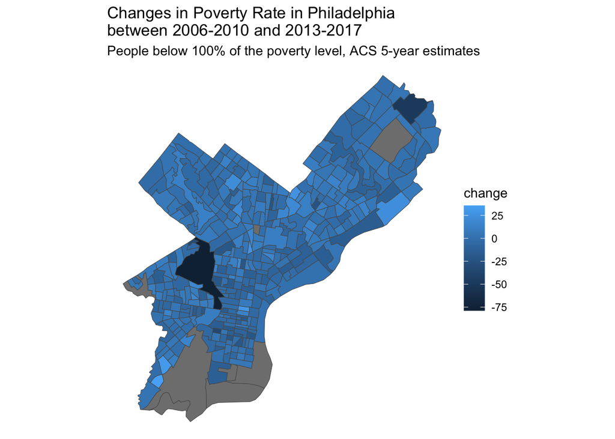

```r
# Visualizing the poverty change
library(sf)
library(ggplot2)

#| fig-height:9
results_poverty %>%
  ggplot() +
    geom_sf(aes(fill = change)) +
    theme_minimal() +
    theme_void() +
    labs( # adjusts the labels
      title = "Changes in Poverty Rate in Philadelphia \nbetween 2006-2010 and 2013-2017",
      subtitle = "People below 100% of the poverty level, ACS 5-year estimates")
```

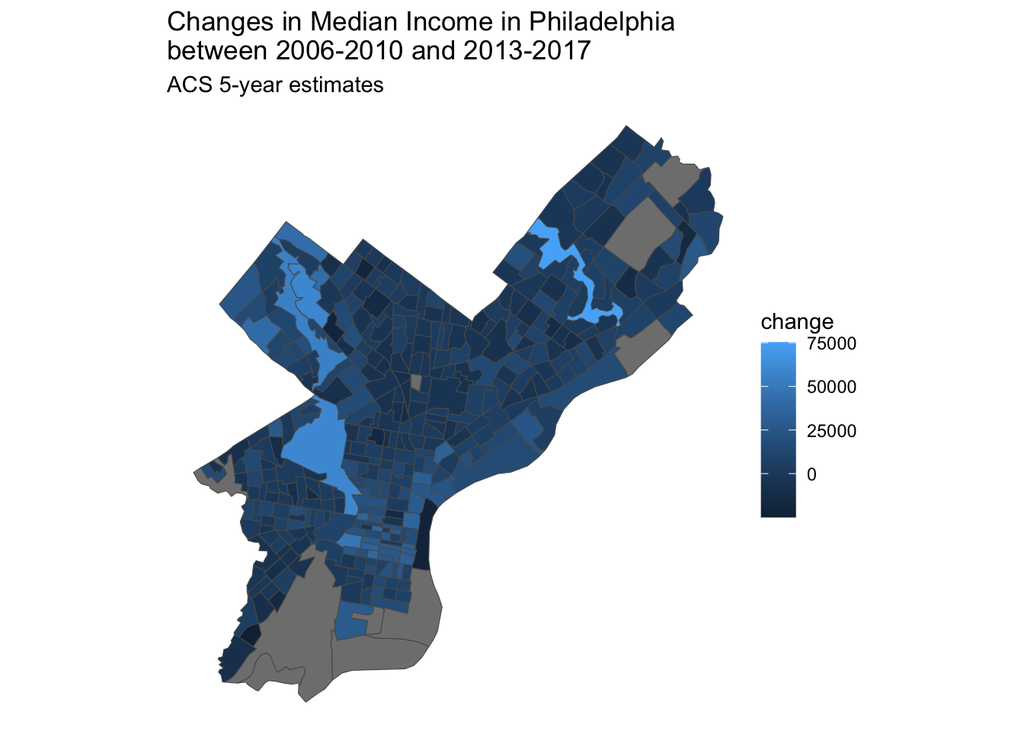

```r
# Visualizing the income change

#| fig-height:9
results_income %>%
  ggplot() +
    geom_sf(aes(fill = change)) +
    theme_minimal() +
    theme_void() +
    labs( # adjusts the labels
      title = "Changes in Median Income in Philadelphia \nbetween 2006-2010 and 2013-2017",
      subtitle = "ACS 5-year estimates")
```

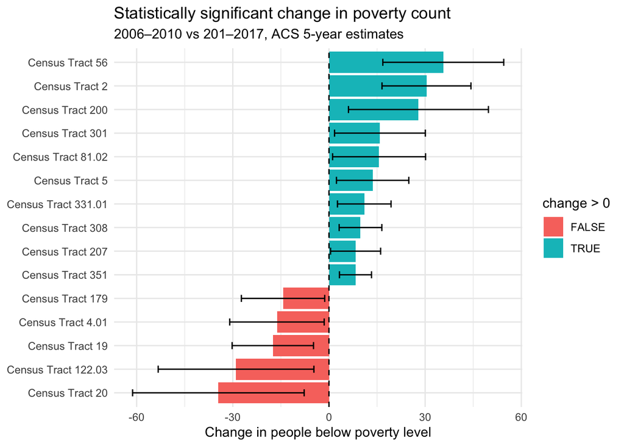

```r
# Visualize with error bars
results_poverty %>%
  filter(significant) %>%
  arrange(desc(significant)) %>%
  mutate(NAME = str_remove(NAME, ", Philadelphia County, Pennsylvania")) %>%
  slice_head(n = 15) %>%
  ggplot(aes(x = reorder(NAME, change), y = change)) +
  geom_col(aes(fill = change > 0)) +
  geom_errorbar(aes(ymin = change - moe_diff,
                    ymax = change + moe_diff), width = 0.3) +
  geom_hline(yintercept = 0, linetype = "dashed") +
  coord_flip() +
  theme_minimal() +
  labs(title = "Statistically significant change in poverty count",
       subtitle = "2006–2010 vs 201–2017, ACS 5-year estimates",
       x = NULL, y = "Change in people below poverty level")
```

## Part 3: Adjudicate

### The Article’s Claims

The article makes many claims regarding the changes to Philadelphia’s poverty rate, white poverty, and income levels. The section below sorts out the different claims by three distinctions: 1) Supported by the Data, 2) Not Supported by the data, and 3) Cannot be Determined

#### 1) Supported by the Data

The article makes a claim that Fairhill is the neighborhood with the highest inequality based on percentage in poverty (61%) based on the ACS5 2017 data. Drawing from our own analysis of the data through the census tracts, the average poverty rate of the three census tracts that best fit the Fairhill neighborhood boundary is 61.5%, thus demonstrating that the claims in the article regarding the high inequality in Fairhill are supported by the data.

```r
fairhill <- phl_data_2017 %>%
  filter(GEOID %in% c("42101017500", "42101017601", "42101017602"))

mean_fairhill <-
  mean(fairhill$poverty_pct)

print(mean_fairhill)
```

```
[1] 61.50695
```

#### 2) Not Supported by the Data

The article goes in depth into the rise of poverty in the neighborhood of Eastwick. From their data, the authors claim that there was a rise of 14 percentage points in the poverty rate in Eastwick: Rising from a 12% poverty rate in 2010 to a 26% poverty rate in 2017. When comparing to the ACS data at the census tract level used in this project, it is observed that the average of the four census tracts the most closely aligns with the neighborhood of Eastwick results in a 17% increase in the percentage of poverty that is higher than the reported figures in the article.

```r
eastwick <- results_poverty %>%
  filter(GEOID %in% c("42101005400", "42101005600", "42101005500", "42101006000" ))

mean_eastwick <-
  mean(eastwick$change)

print(mean_eastwick)
```

```
[1] 17.0232
```

#### 3) Cannot be Determined

The claims stated by the article regarding white poverty cannot be determined as there is no race-disaggregated data relating to the poverty rate. Some of the article’s other claims relating to specific neighborhoods that do not line up with census tract boundaries also cannot be determined.

## Part 4: Rewrite

New census data confirms that poverty in Philadelphia remains deeply concentrated, with tracts in the Fairhill area of North Philadelphia showing poverty rates averaging around 61 percent. This is among the highest in the city. However, the picture is more uncertain than the headline figures in the article suggest. Of Philadelphia’s 384 census tracts, only 63 show a change in poverty rate between 2006–2010 and 2013–2017 that is statistically distinguishable from zero at 90% confidence. For the remaining 313 tracts, the margins of error in the underlying survey data are wide enough that the apparent changes in poverty rate cannot be reliably separated from sampling noise. Thus, claims about dramatic poverty increases in specific neighborhoods and about surging white poverty across the Northeast rest on point estimates that the data cannot confidently support at the tract level.